# Implementando ICs com amostras do Last.fm

Nazareno e Lívia

## Os dados

```r
set.seed(12345)

lastfm = read_csv(here::here("data/experimento-lastfm.csv"),
                  col_types = cols(.default = col_double(),
                                   user = col_character()))

samples_lastfm = lastfm %>%
  sample_n(300) %>%
  select(news, old, mediana_pop)

glimpse(samples_lastfm)
```

```
## Observations: 300
## Variables: 3
## $ news        <dbl> 25, 13, 21, 18, 10, 11, 29, 51, 23, 11, 22, 35, 77...
## $ old         <dbl> 103, 61, 62, 180, 55, 68, 120, 45, 61, 116, 68, 83...
## $ mediana_pop <dbl> 5.966097, 5.745970, 5.195969, 5.595928, 5.900597, ...
```

## Proporção de artistas novos e popularidade

Utilizaremos ICs para estimar duas métricas sobre os usuários do LastFM em geral durante um período de 6 meses. Em ambos os casos faremos isso a partir de uma amostra de 300 usuários. As duas métricas são:

#### Qual a proporção de novos artistas escutados pelos usuários

```r
set.seed(1998)
news_df = samples_lastfm %>% mutate(prop_news = news/(news+old))
news_theta_c = news_df %>% pull(prop_news) %>% mean()
news_theta_c
```

```
## [1] 0.242366
```

*Manualmente*

```r
samples_news = function(df, n) {
  df %>%
    select(news, old) %>%
    mutate(theta_c = (news/(news+old)))
}


thetas = samples_news(samples_lastfm)
thetas
```

| news | old | theta_c |
| --- | --- | --- |
| 25 | 103 | 0.19531250 |
| 13 | 61 | 0.17567568 |
| 21 | 62 | 0.25301205 |
| 18 | 180 | 0.09090909 |
| 10 | 55 | 0.15384615 |
| 11 | 68 | 0.13924051 |
| 29 | 120 | 0.19463087 |
| 51 | 45 | 0.53125000 |
| 23 | 61 | 0.27380952 |
| 11 | 116 | 0.08661417 |

[output cut: 290 more lines]

```r
iterations = 10000

bootstrap_step <- function(x){
  selected_data = x %>% pull(theta_c)
  boot_x <- sample(selected_data,
                   size = NROW(x),
                   replace = TRUE)
  return(mean(boot_x))
}
```

```r
reamostragens = tibble(i = 1:iterations) %>%
  mutate(theta_c_s = map_dbl(i, ~ bootstrap_step(thetas)))

reamostragens
```

| i | theta_c_s |
| --- | --- |
| 1 | 0.2462931 |
| 2 | 0.2432210 |
| 3 | 0.2587116 |
| 4 | 0.2339104 |
| 5 | 0.2457079 |
| 6 | 0.2378627 |
| 7 | 0.2556711 |
| 8 | 0.2439286 |
| 9 | 0.2348442 |
| 10 | 0.2434281 |

[output cut: 9990 more lines]

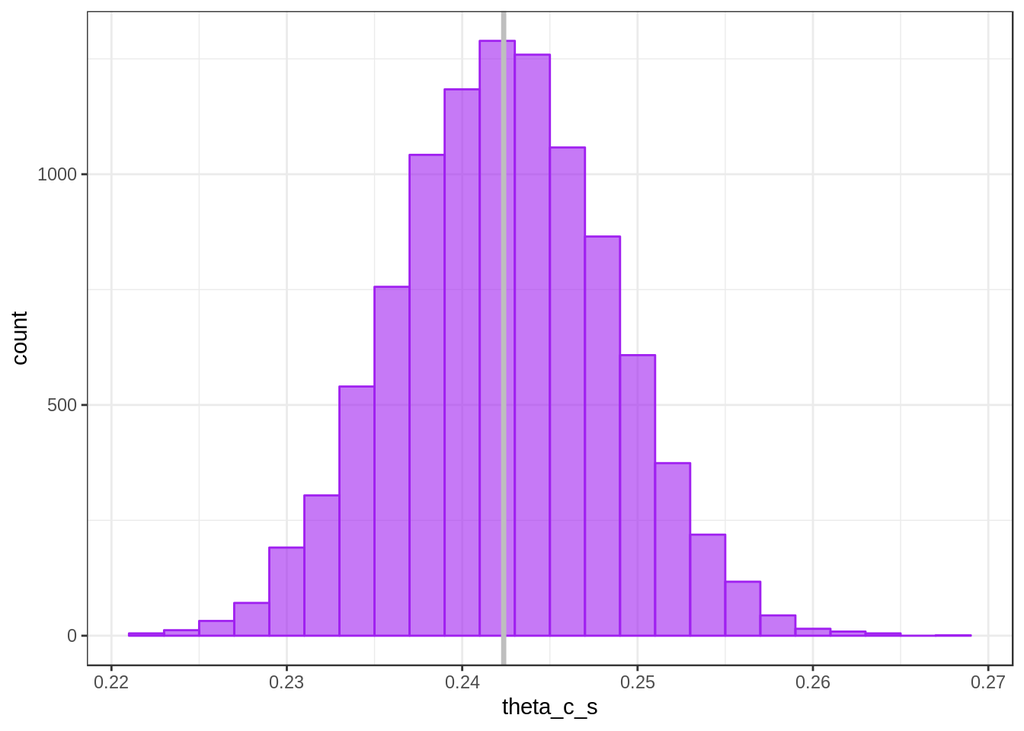

```r
reamostragens %>%
  ggplot(aes(x = theta_c_s)) +
  geom_histogram(binwidth = .002,
                 colour = "purple",
                 fill = "purple",
                 alpha=.6) +
  geom_vline(xintercept = news_theta_c,
             color = "grey",
             size = 1.2)
```

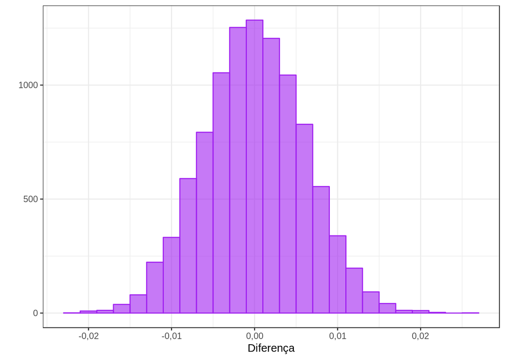

```r
reamostragens %>%
  ggplot(aes(x = theta_c_s - news_theta_c)) +
  geom_histogram(binwidth = .002,
                 colour = "purple",
                 fill = "purple",
                 alpha=.6) +
  labs(x="Diferença", y="")
```

Pelo segundo gráfico, percebe-se que a reamostragem manteve os dados muito parecidos com a amostra original, já que a diferença entre os parâmetros desta com o conjunto de reamostras foi baixa.

*Usando biblioteca*

```r
bootstrap_step <- function(x, i){
return(x %>%
        slice(i) %>%
        mutate(theta_c = (news/(news+old))) %>%
        pull(theta_c))

}

bootstrap_step_summarise <- function(x, i){
return(x %>%
        slice(i) %>%
        summarise(theta_c = mean(news/(news+old))) %>%
        pull(theta_c))

}
booted=boot(data = samples_lastfm, statistic=bootstrap_step, R = iterations)
```

Usando a biblioteca *boot*, os resultados são muito semelhantes dos anteriormente vistos.

O método nos leva a considerar que, provavelmente, os usuários têm o hábito de diversificar os artistas escutados com a razão de um um quarto.

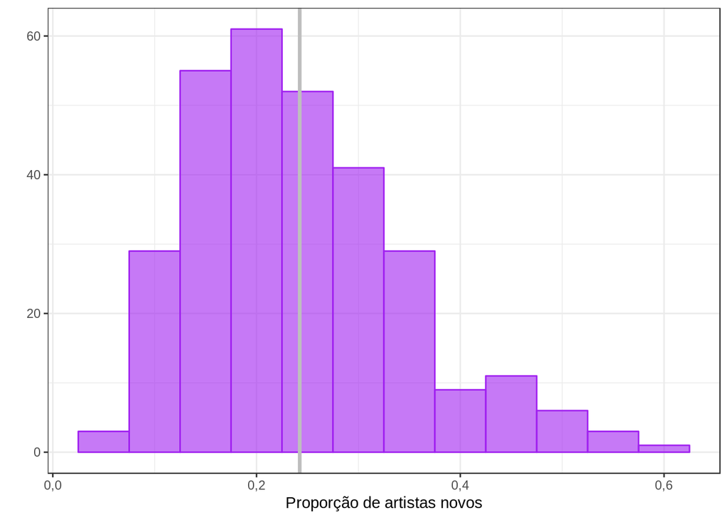

```r
booted_t = tidy(booted,
          conf.level = .95,
          conf.method = "perc",
          conf.int = TRUE)

booted_t %>%
  ggplot(aes(x = statistic)) +
  geom_histogram(binwidth = .05,
                 colour = "purple",
                 fill = "purple",
                 alpha=.6) +
  geom_vline(xintercept = news_theta_c,
             color = "grey",
             size = 1.2) +
  labs(x="Proporção de artistas novos", y="")
```

```r
boot(data = samples_lastfm, statistic=bootstrap_step_summarise,R = iterations)
```

```
##
## ORDINARY NONPARAMETRIC BOOTSTRAP
##
##
## Call:
## boot(data = samples_lastfm, statistic = bootstrap_step_summarise,
##     R = iterations)
##
##
## Bootstrap Statistics :
##     original       bias    std. error
## t1* 0,242366 5,896938e-05    0,006026
```

#### Para os usuários que gostam de música muito pop (mediana_pop > 5), qual a correlação entre a popularidade mediana dos artistas escutados e a proporção dos artistas escutados que eram novos.

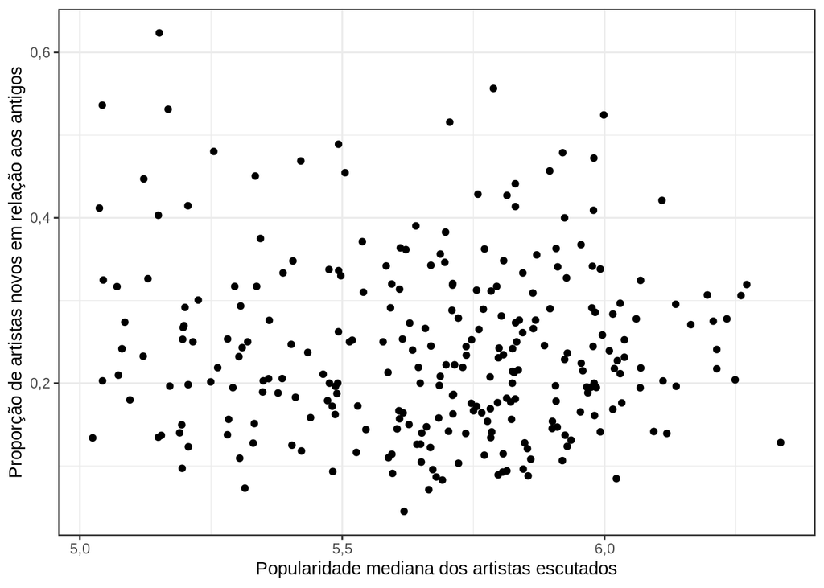

```r
pop_users = news_df %>% filter(mediana_pop>5)
correlation = cor(select(news_df, mediana_pop),  select(news_df,prop_news)) #-0,05679804
  pop_users %>% ggplot(aes(x=mediana_pop, y=prop_news), color = "purple", alpha=.6) + geom_point() + labs(x="Popularidade mediana dos artistas escutados", y="Proporção de artistas novos em relação aos antigos")
```

Vamos verificar se isso também acontecerá com as amostras obtidas por meio do bootstrap.

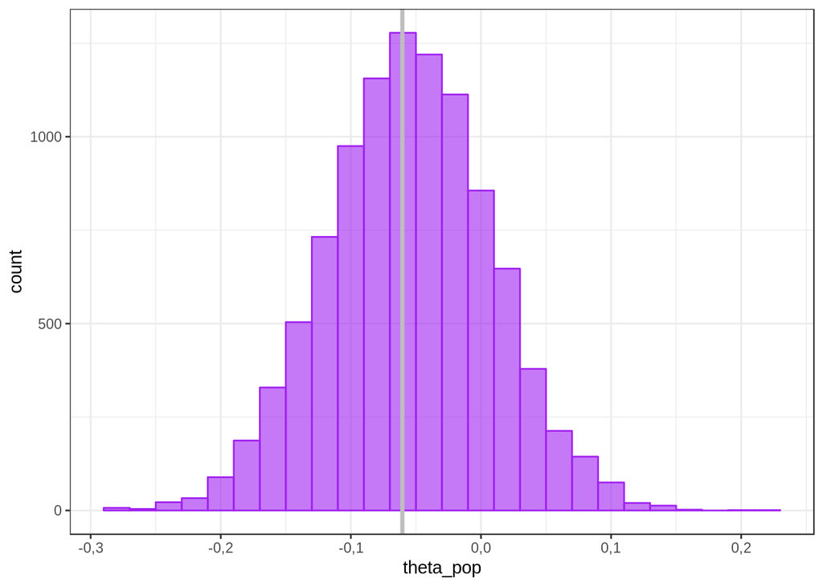

```r
cor_step <- function(x){
  amostra_x = sample_n(x, size = NROW(x), replace = TRUE)
  return(cor(amostra_x$prop_news, amostra_x$mediana_pop))
}

reamostragens = tibble(i = 1:10000) %>%
  mutate(theta_pop = map_dbl(i, ~ cor_step(pop_users)))

reamostragens %>%
  ggplot(aes(x = theta_pop)) +
  geom_histogram(binwidth = .02,
                 colour = "purple",
                 fill = "purple",
                 alpha=.6) +
  geom_vline(xintercept = correlation,
             color = "grey",
             size = 1.2)
```

```r
cor_step <- function(x, i){
  temp = pop_users %>%
        slice(i)  %>%
    mutate(prop = news/(news+old))
     return(cor(temp$mediana_pop, temp$prop))
}
boot_lib = boot(data = pop_users, statistic=cor_step,R = 10000)
tidy(boot_lib, conf.level = .95,conf.method = "perc",conf.int = TRUE)
```

| statistic | bias | std.error | conf.low | conf.high |
| --- | --- | --- | --- | --- |
| -0,05679804 | 0,001124561 | 0,06373949 | -0,1793928 | 0,06934158 |

Podemos ver que, tanto para a análise manual quanto para a utilizando biblioteca, os parâmtros das amostras estão muito próximo de zero. Logo, conclui-se que não há correlação entre as variáveis, ou seja, escutar artistas muito populares não está correlacionado com o proporção de artistas novos, em relação aos antigos, escutados.

_Based on: https://github.com/cienciadedados-ufcg/inferencia-iat-scores/blob/master/reports/analise-um-lab.Rmd